# Population Simulation

# Initial Values

These are the parameters to construct our copula with tail dependence for which we obtain our environmental noise.

- **n:** 10000
- **dim:** 10
- **rho:** 0.1
- **thresh:** 0.4
- **eps_sd:** 1

These are the values that we have when we simulate our population throughout time.

This is if we set a seed for our program.

- **setseed:** FALSE
- **seed:** 10

This is where we obtain additional information we want to include in our document.

- **filename:** testtext
- **fileext:** .txt

# Construction of a Tail Dependent Random Variable

Here we construct our copula with tail dependence with the newCopulaWithTailDependence function.

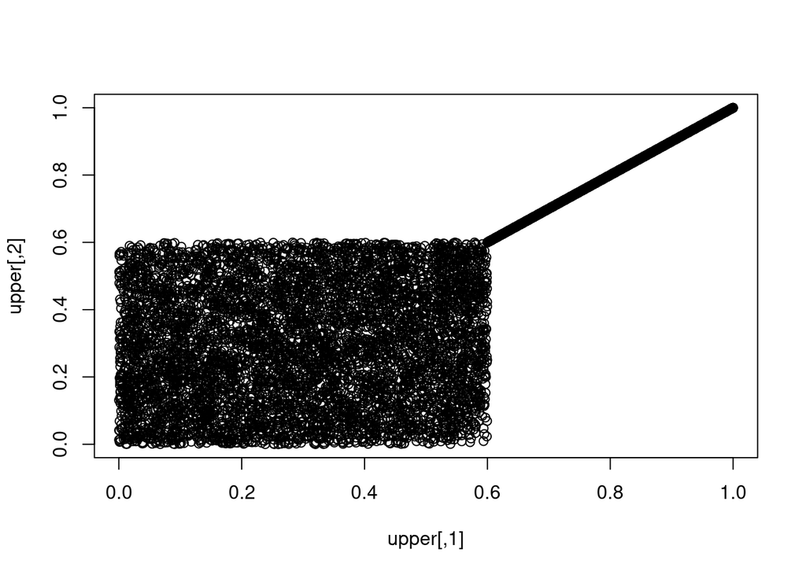

```r
upper<-newCopulaWithTailDependece(params$n,params$dim,params$rho,0,1-params$thresh)
lower<-newCopulaWithTailDependece(params$n,params$dim,params$rho,params$thresh,1)
both<-newCopulaWithTailDependece(params$n,params$dim,params$rho,params$thresh/2,1-(params$thresh/2))
plot(upper)
```

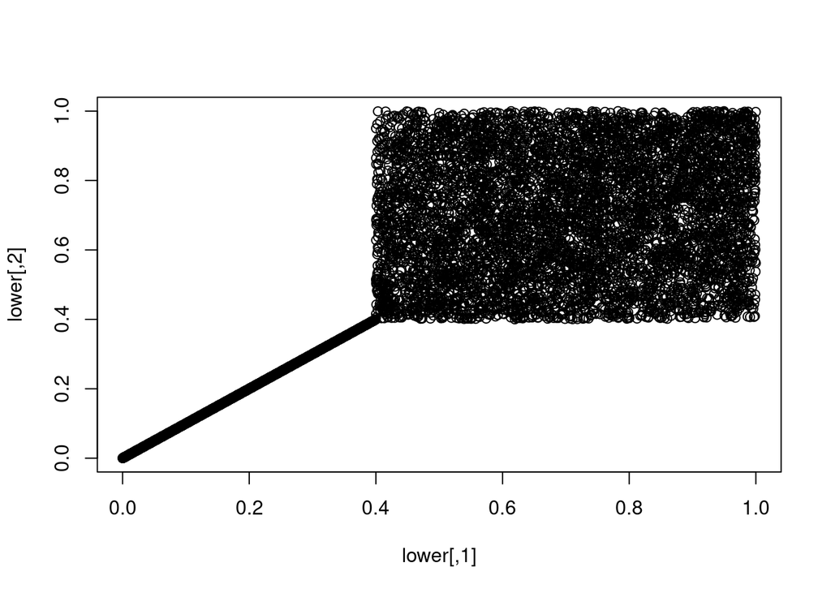

```r
plot(lower)
```

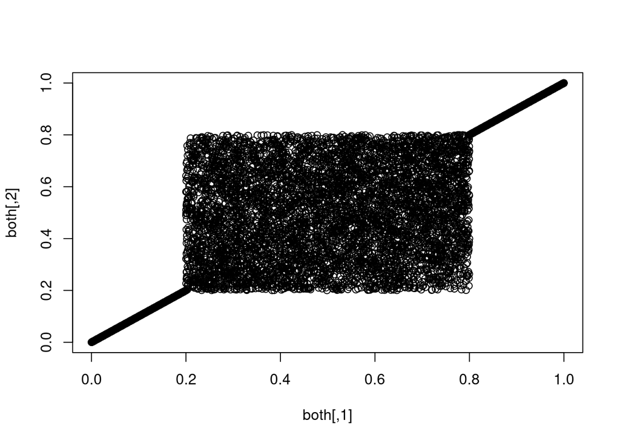

```r
plot(both)
```

# Transformation of our Random Variable and Construction of New Random Variables

We now transforms all of our marginals of our 10-dimensional copula with into normal marginals.

```r
upper<-qnorm(upper,sd=params$eps_sd)
lower<-qnorm(lower,sd=params$eps_sd)
both<-qnorm(both,sd=params$eps_sd)
```

We now find the rho parameter to construct a 10-variate normal copula that has the same value for the variance of the sum of the marginals as our tail dependent random variable

```r
varSumRetain <- sum((1/params$eps_sd^2)*cov(upper))
rho <- findNormalCopulaParam(params$dim, varSumRetain)
newNormalCop <- normalCopula(param = rho,dim =params$dim)
newNormCop <- rCopula(params$n, newNormalCop)
```

We new transform this normal copula into normal marginals.

```r
multiNorm <- qnorm(newNormCop,sd=params$eps_sd)
```

We now create our comonotonic random variable with dimension 10

```r
temp <- rnorm(params$n, sd=params$eps_sd)
com <- matrix(data=replicate(n=params$dim,temp),ncol=params$dim)
```

This is the empirical cumulative density function of three random variables along with the cases of comonotonic and not comonotonic. These three random variables are the sum of the 10 marginals of each the three cases. The variance of the sum of these random variables respectively are:

- **comonotonic:** 99.9140996 99.9140996
- **comonotonic** in the upper tail: 79.8967116 79.8967116
- **comonotonic** in the lower tail: 79.5946904 79.5946904
- **comonotonic** in both tails: 90.3214654 90.3214654
- **not comonotonic:** 80.6631175 80.6631175

The following is the variance of the first marginal of each of the cases:

- **comonotonic:** 0.999141
- **comonotonic** in the upper tail: 1.0158238
- **comonotonic** in the lower tail: 1.0079902
- **comonotonic** in both tails: 1.0078695
- **not comonotonic:** 1.0012703

This is the ecdfplot of the sum of the marginals of each of the three random variables.

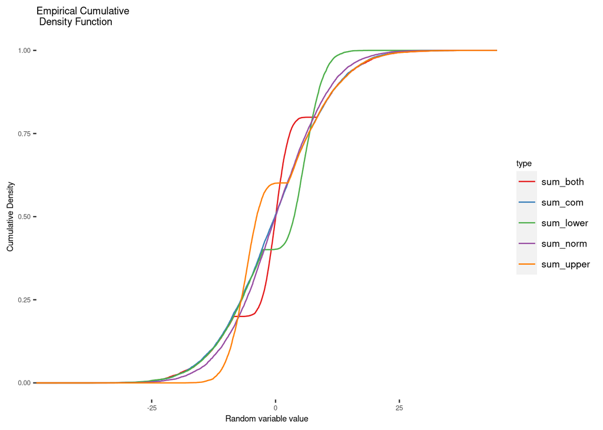

We have three random variables where each of them have 10 marginals. Each of these random variables represents the environmental noise on a population each with 10 metapopulations. We use a stochastic ricker model to model how the population fluctuates over time

```r
ricker <-function(curpop,r,k,eps){
  return(curpop*exp(r*(1-(curpop/k))+eps))
}
```

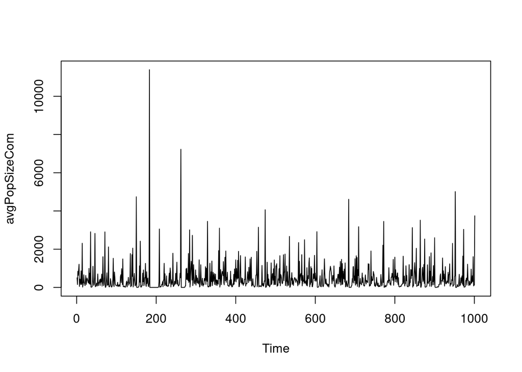

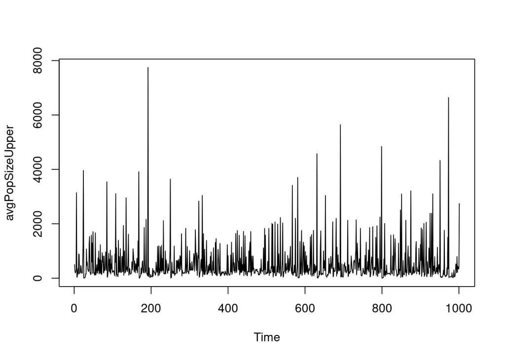

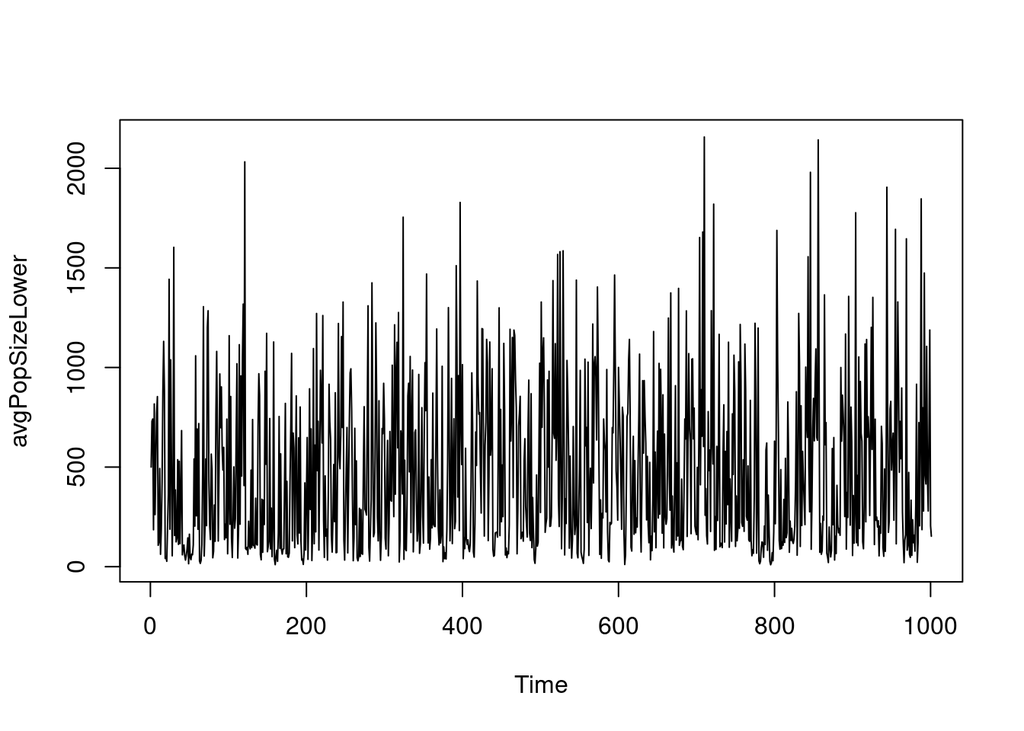

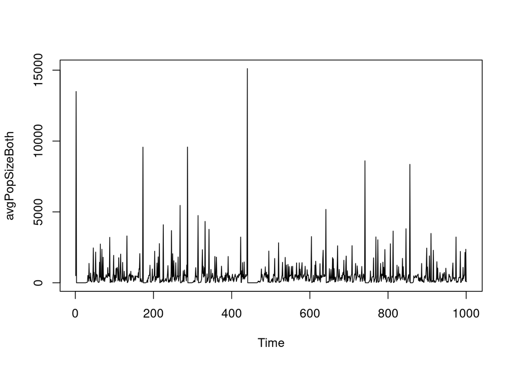

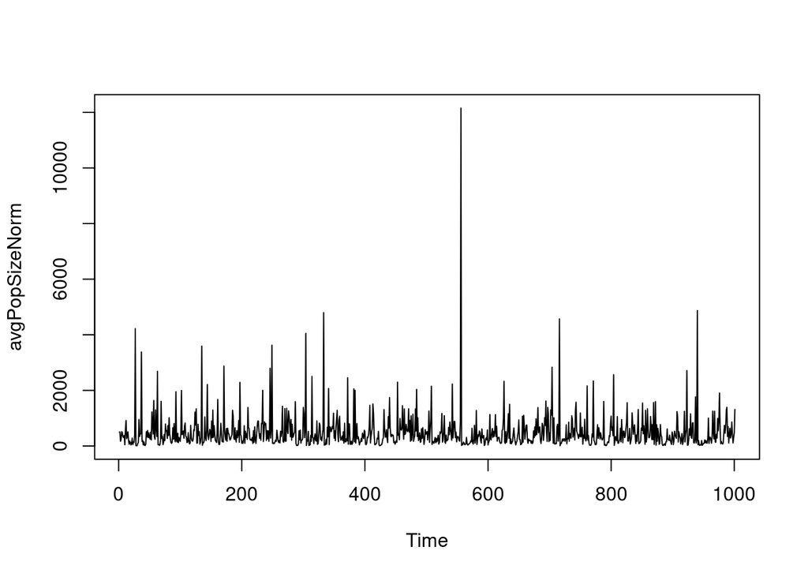

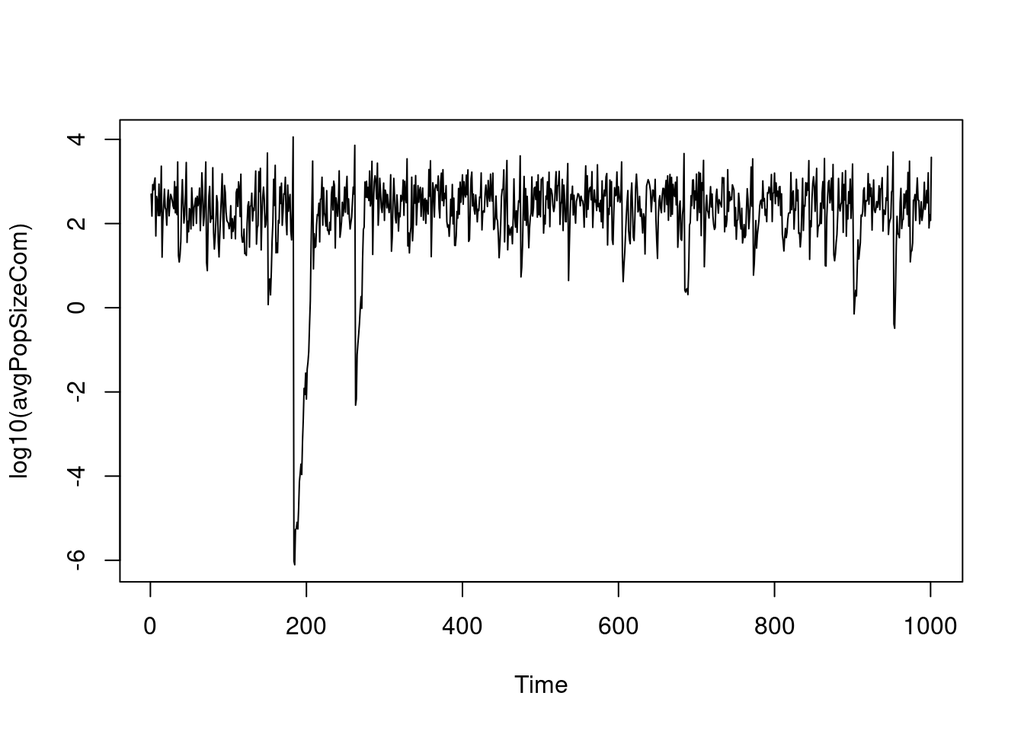

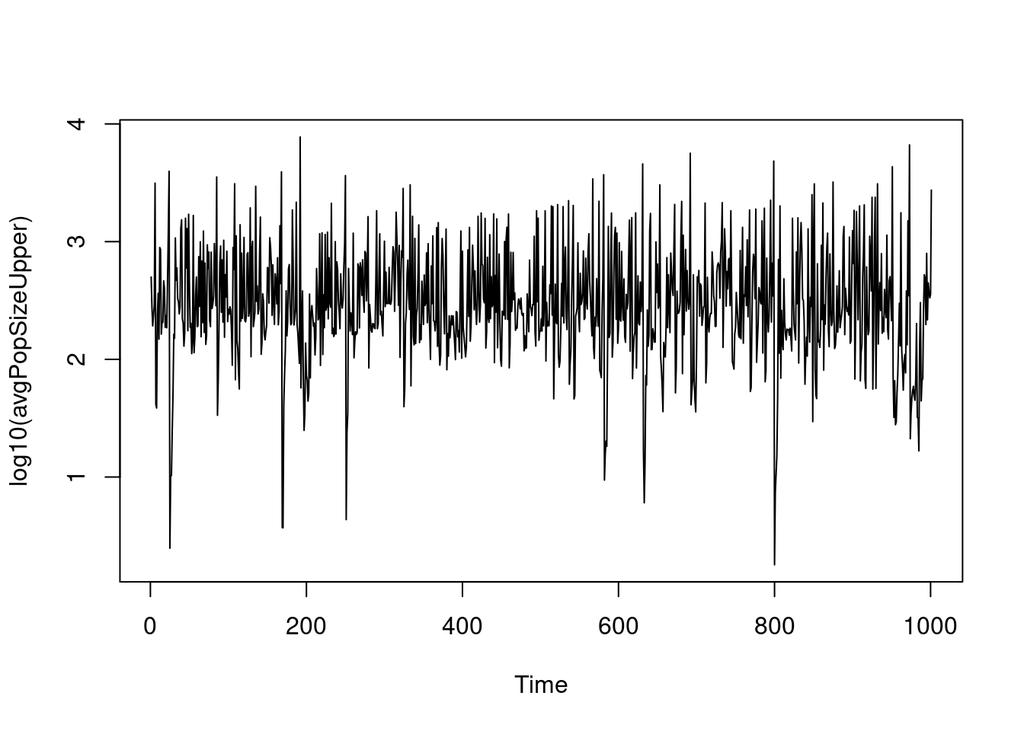

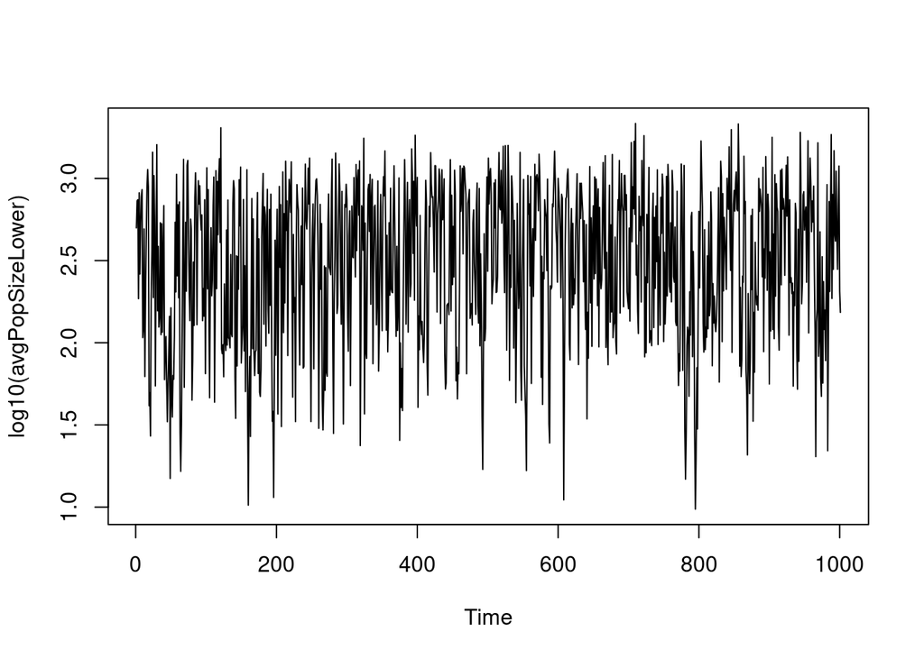

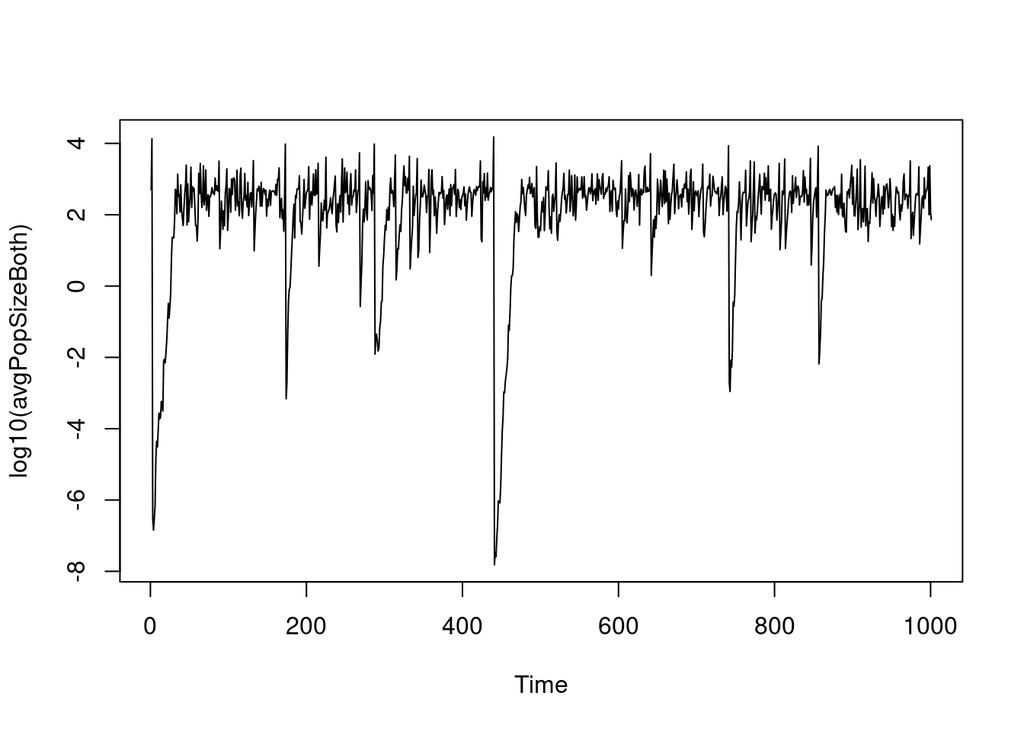

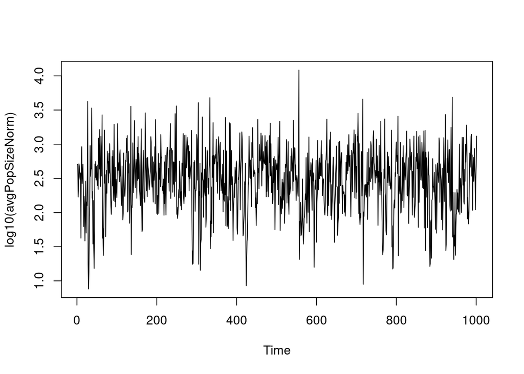

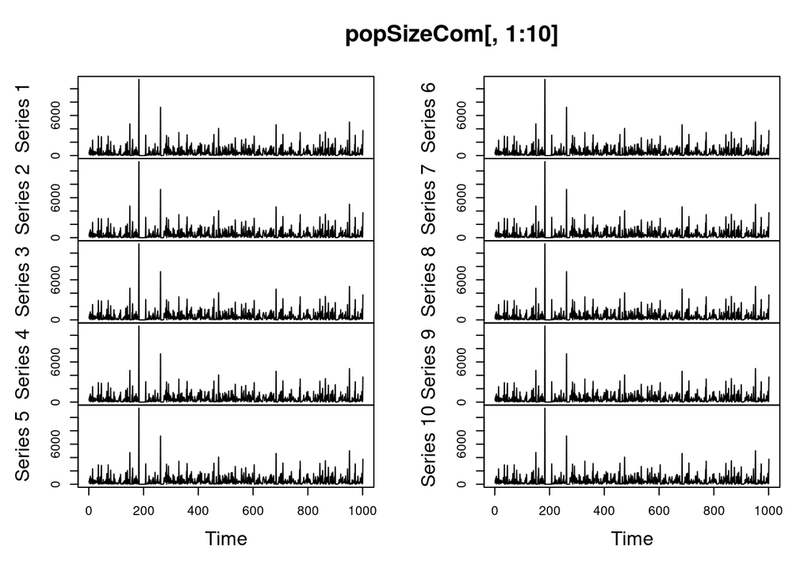

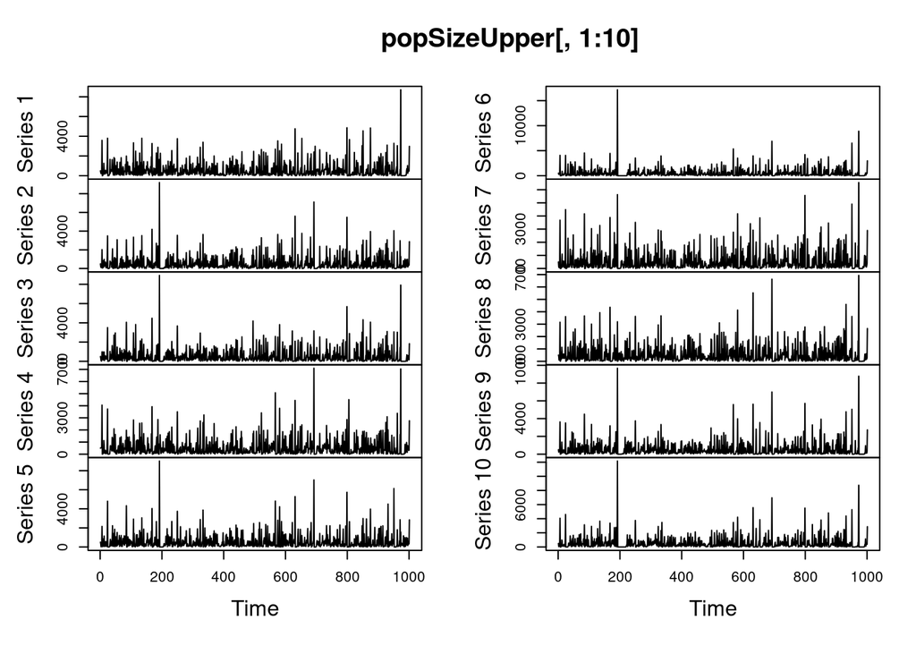

[3 more figures not shown]

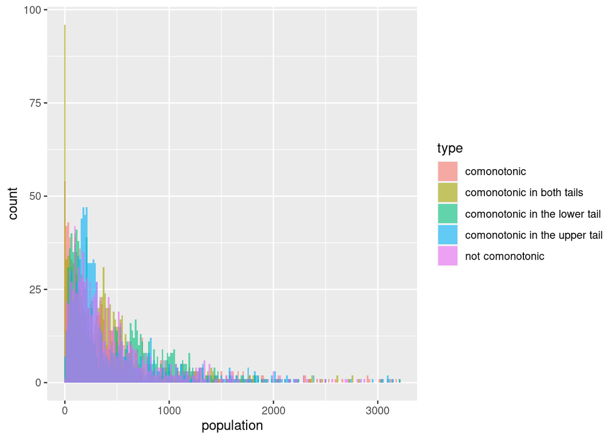

```r
upB <- max(quantile(avgPopSizeCom,0.98),quantile(avgPopSizeUpper,0.98),quantile(avgPopSizeLower,0.98),quantile(avgPopSizeBoth,0.98),quantile(avgPopSizeNorm,0.98))

c <- data.frame(population =avgPopSizeCom[avgPopSizeCom<upB] )
u <- data.frame(population =avgPopSizeUpper[avgPopSizeUpper<upB] )
l <- data.frame(population =avgPopSizeLower[avgPopSizeLower<upB] )
b <- data.frame(population =avgPopSizeBoth[avgPopSizeBoth<upB] )
n <- data.frame(population =avgPopSizeNorm[avgPopSizeNorm<upB] )

c$type <- "comonotonic"
u$type <- "comonotonic in the upper tail"
l$type <- "comonotonic in the lower tail"
b$type <- "comonotonic in both tails"
n$type <- "not comonotonic"

popfreq <- rbind(c,u,l,b,n)

ggplot(popfreq,aes(population,fill=type)) + geom_histogram(bins=200, alpha =0.6, position ='identity')
```

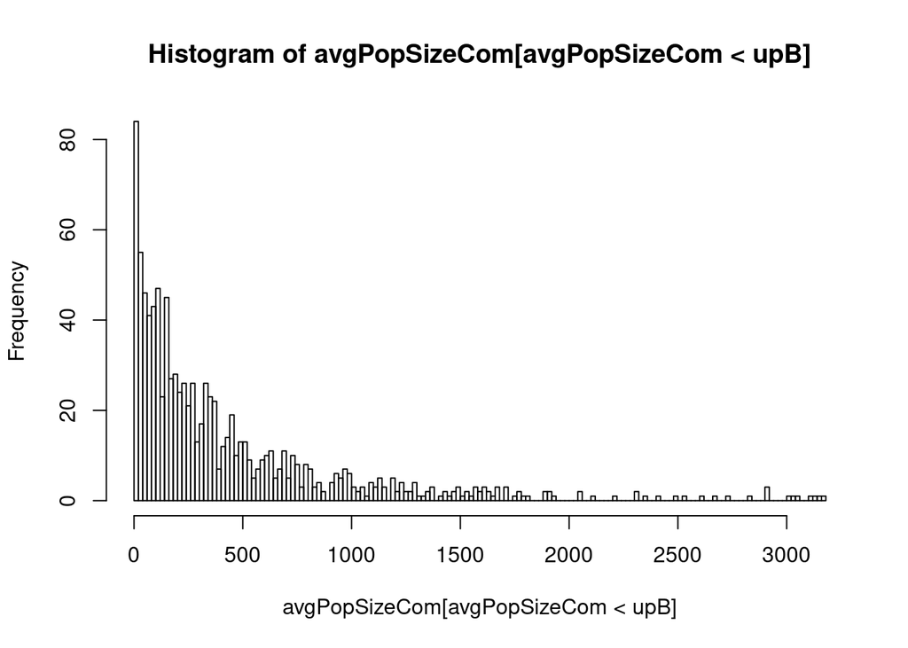

```r
hist(avgPopSizeCom[avgPopSizeCom<upB],breaks=200)
```

```r
print(paste0("mean: ", mean(avgPopSizeCom)," median: ", median(avgPopSizeCom)))
```

```
## [1] "mean: 483.000864870206 median: 249.904387856845"
```

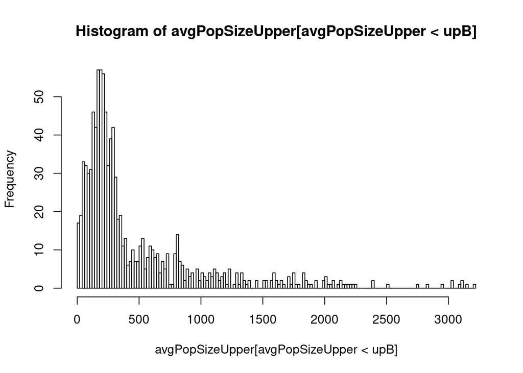

```r
hist(avgPopSizeUpper[avgPopSizeUpper<upB],breaks=200)
```

```r
print(paste0("mean: ", mean(avgPopSizeUpper)," median: ", median(avgPopSizeUpper)))
```

```
## [1] "mean: 514.912023563908 median: 260.730652743086"
```

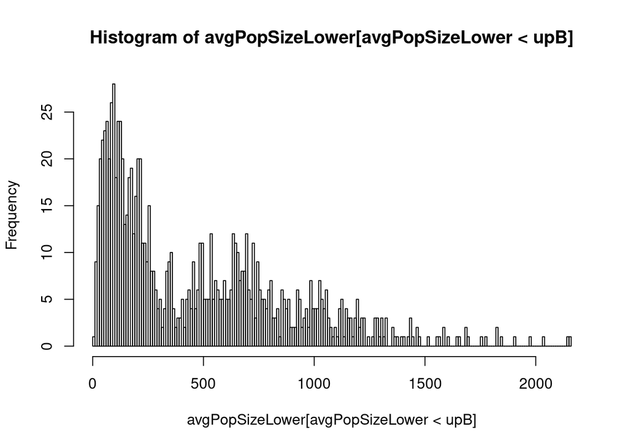

```r
hist(avgPopSizeLower[avgPopSizeLower<upB],breaks=200)
```

```r
print(paste0("mean: ", mean(avgPopSizeLower)," median: ", median(avgPopSizeLower)))
```

```
## [1] "mean: 474.497588709694 median: 343.885117011424"
```

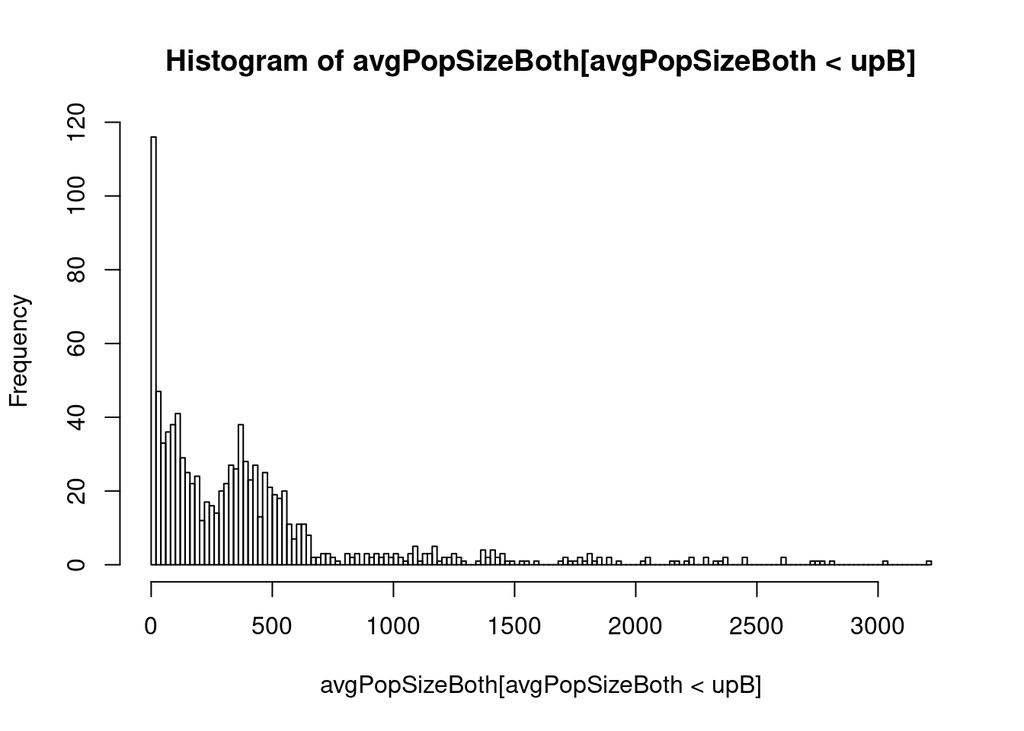

```r
hist(avgPopSizeBoth[avgPopSizeBoth<upB],breaks=200)
```

```r
print(paste0("mean: ", mean(avgPopSizeBoth)," median: ", median(avgPopSizeBoth)))
```

```
## [1] "mean: 522.061987961597 median: 310.162738250917"
```

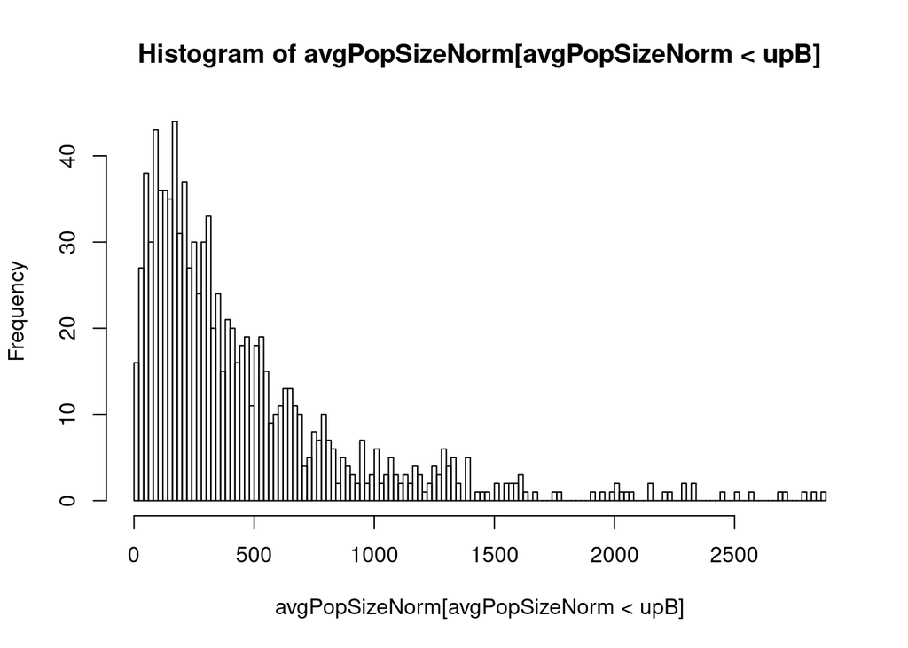

```r
hist(avgPopSizeNorm[avgPopSizeNorm<upB],breaks=200)
```

```r
print(paste0("mean: ", mean(avgPopSizeNorm)," median: ", median(avgPopSizeNorm)))
```

```
## [1] "mean: 494.215718538893 median: 310.423084373725"
```